# Churn Prediction

#### Discription

Churner is generally defined as a customer who stops using a product or service for a given period of time. The definition of churner will vary on the type of the organization. Like in case of Game Industry churner will be one who has not login to their server within a particular interval or the one who has not move to next level in the game. In case of flipkart service churner will be one who has not visited the website within particular interval or the one who has not ordered anything on it in a given interval of time. This interval will vary based on the organization and based on the application the user is involved in.

The predictive model should be robust enough to handle the variance of interval of not using a serive or product very intelligently.

**Aim :** Do the analysis of the given dataset and build the model to investigate and predict which of the customers are more likely to leave the bank soon using different Machine Learning algorithms and compare their results.

**Dataset** Size: 10,000  
Attributes: 14

```
RowNumber
CustomerId
Surname
CreditScore
Geography
Gender
Age
Tenure
Balance
NumOfProducts
HasCrCard
IsActiveMember
EstimatedSalary
Exited (this is the label of the the dataset)
```

**Algorithms and Results**

[output not shown]

```python
#import the required libraries
import pandas as pd
import matplotlib.pyplot as plt
import seaborn as sns
import numpy as np
```

#### Loading dataset and getting some basic information about it

```python
#load the dataset
data = pd.read_csv("Data/Churn_Modelling.csv",header=0)
#pick the first 5 rows of our dataset
data.head()
```

|  | RowNumber | CustomerId | Surname | CreditScore | Geography | Gender | Age | Tenure | Balance | NumOfProducts | HasCrCard | IsActiveMember | EstimatedSalary | Exited |
| --- | --- | --- | --- | --- | --- | --- | --- | --- | --- | --- | --- | --- | --- | --- |
| 0 | 1 | 15634602 | Hargrave | 619 | France | Female | 42 | 2 | 0.00 | 1 | 1 | 1 | 101348.88 | 1 |
| 1 | 2 | 15647311 | Hill | 608 | Spain | Female | 41 | 1 | 83807.86 | 1 | 0 | 1 | 112542.58 | 0 |
| 2 | 3 | 15619304 | Onio | 502 | France | Female | 42 | 8 | 159660.80 | 3 | 1 | 0 | 113931.57 | 1 |
| 3 | 4 | 15701354 | Boni | 699 | France | Female | 39 | 1 | 0.00 | 2 | 0 | 0 | 93826.63 | 0 |
| 4 | 5 | 15737888 | Mitchell | 850 | Spain | Female | 43 | 2 | 125510.82 | 1 | 1 | 1 | 79084.10 | 0 |

```python
#pick the last 5 rows of our dataset
data.tail()
```

|  | RowNumber | CustomerId | Surname | CreditScore | Geography | Gender | Age | Tenure | Balance | NumOfProducts | HasCrCard | IsActiveMember | EstimatedSalary | Exited |
| --- | --- | --- | --- | --- | --- | --- | --- | --- | --- | --- | --- | --- | --- | --- |
| 9995 | 9996 | 15606229 | Obijiaku | 771 | France | Male | 39 | 5 | 0.00 | 2 | 1 | 0 | 96270.64 | 0 |
| 9996 | 9997 | 15569892 | Johnstone | 516 | France | Male | 35 | 10 | 57369.61 | 1 | 1 | 1 | 101699.77 | 0 |
| 9997 | 9998 | 15584532 | Liu | 709 | France | Female | 36 | 7 | 0.00 | 1 | 0 | 1 | 42085.58 | 1 |
| 9998 | 9999 | 15682355 | Sabbatini | 772 | Germany | Male | 42 | 3 | 75075.31 | 2 | 1 | 0 | 92888.52 | 1 |
| 9999 | 10000 | 15628319 | Walker | 792 | France | Female | 28 | 4 | 130142.79 | 1 | 1 | 0 | 38190.78 | 0 |

```python
#now see the range of information about our numberic features of our dataset
#Note textual features are not represented here
data.describe()
```

|  | RowNumber | CustomerId | CreditScore | Age | Tenure | Balance | NumOfProducts | HasCrCard | IsActiveMember | EstimatedSalary | Exited |
| --- | --- | --- | --- | --- | --- | --- | --- | --- | --- | --- | --- |
| count | 10000.00000 | 1.000000e+04 | 10000.000000 | 10000.000000 | 10000.000000 | 10000.000000 | 10000.000000 | 10000.00000 | 10000.000000 | 10000.000000 | 10000.000000 |
| mean | 5000.50000 | 1.569094e+07 | 650.528800 | 38.921800 | 5.012800 | 76485.889288 | 1.530200 | 0.70550 | 0.515100 | 100090.239881 | 0.203700 |
| std | 2886.89568 | 7.193619e+04 | 96.653299 | 10.487806 | 2.892174 | 62397.405202 | 0.581654 | 0.45584 | 0.499797 | 57510.492818 | 0.402769 |
| min | 1.00000 | 1.556570e+07 | 350.000000 | 18.000000 | 0.000000 | 0.000000 | 1.000000 | 0.00000 | 0.000000 | 11.580000 | 0.000000 |
| 25% | 2500.75000 | 1.562853e+07 | 584.000000 | 32.000000 | 3.000000 | 0.000000 | 1.000000 | 0.00000 | 0.000000 | 51002.110000 | 0.000000 |
| 50% | 5000.50000 | 1.569074e+07 | 652.000000 | 37.000000 | 5.000000 | 97198.540000 | 1.000000 | 1.00000 | 1.000000 | 100193.915000 | 0.000000 |
| 75% | 7500.25000 | 1.575323e+07 | 718.000000 | 44.000000 | 7.000000 | 127644.240000 | 2.000000 | 1.00000 | 1.000000 | 149388.247500 | 0.000000 |
| max | 10000.00000 | 1.581569e+07 | 850.000000 | 92.000000 | 10.000000 | 250898.090000 | 4.000000 | 1.00000 | 1.000000 | 199992.480000 | 1.000000 |

```python
data.dtypes
```

```
RowNumber            int64
CustomerId           int64
Surname             object
CreditScore          int64
Geography           object
Gender              object
Age                  int64
Tenure               int64
Balance            float64
NumOfProducts        int64
HasCrCard            int64
IsActiveMember       int64
EstimatedSalary    float64
Exited               int64
dtype: object
```

```python
#check if the dataset is balanced
print("No of customers Exited :", len(data[data["Exited"] == 1]))
print("No of customers retained :", len(data[data["Exited"] == 0]))
```

```
No of customers Exited : 2037
No of customers retained : 7963
```

No of customers retained are almost 4 times the number of customers exited. so our dataset is biased towards class of customers not exited(retained).

```python
#count the number of unique surname in the dataset
len(data['Surname'].unique())
```

```
2932
```

Total unique Surname is 2932 out of total 10,000 records which means that there are 7068 records which repeated surname and it might effect the churn prediction.

```python
#make a copy of origianal data
cdata = data.copy()
```

#### Geography

```
Geography
France     5014
Germany    2509
Spain      2477
dtype: int64
```

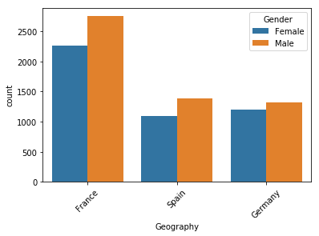

```python
#frequency of each Geography,Gender
#Geography
sns.countplot(x ='Geography',hue='Gender', data=cdata)
plt.xticks(rotation=45)
print(cdata[["Geography"]].groupby("Geography").size())
plt.show()
```

We see that percentage of customers from France ~50% , from Germany ~ 25% and from Spain ~25% and in **every Geography number of Male customers are more than Female customers**

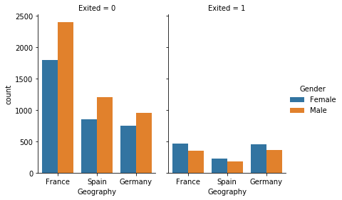

```python
#The number of customers Exited based on Geography
sns.catplot(x="Geography",hue='Gender', col="Exited",data=cdata, kind="count",height=4, aspect=.7)
plt.show()
```

From the above graph it is clear that **Females are more likely to Exit compare to male.** Since in every Geography number of female customers exiting is greater than the number of male customers exiting.

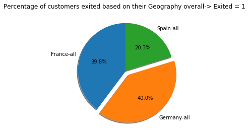

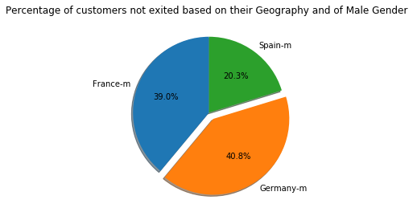

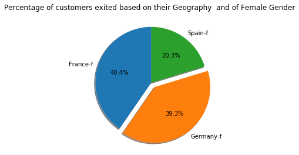

```python
#calculate the number of exit and not exit based on geograpy fe1 -> france exite = 1
fe1 = len(cdata.loc[(cdata['Geography']=='France') & (cdata['Exited']==1)])
ge1 = len(cdata.loc[(cdata['Geography']=='Germany') & (cdata['Exited']==1)])
se1 = len(cdata.loc[(cdata['Geography']=='Spain') & (cdata['Exited']==1)])
exit_1_size = [fe1,ge1,se1]

#fem -> Geography male exite = 1
fem = len(cdata.loc[(cdata['Geography']=='France') & (cdata['Exited']==1) & (cdata['Gender']=="Male")])
gem = len(cdata.loc[(cdata['Geography']=='Germany') & (cdata['Exited']==1) & (cdata['Gender']=="Male")])
sem = len(cdata.loc[(cdata['Geography']=='Spain') & (cdata['Exited']==1) & (cdata['Gender']=="Male")])
exit_m_size = [fem,gem,sem]

#fef -> Geography female exite = 1
fef = len(cdata.loc[(cdata['Geography']=='France') & (cdata['Exited']==1) & (cdata['Gender']=="Female")])
gef = len(cdata.loc[(cdata['Geography']=='Germany') & (cdata['Exited']==1) & (cdata['Gender']=="Female")])
sef = len(cdata.loc[(cdata['Geography']=='Spain') & (cdata['Exited']==1) & (cdata['Gender']=="Female")])
exit_f_size = [fef,gef,sef]


labels = 'France-all', 'Germany-all', 'Spain-all'
labelm = 'France-m', 'Germany-m', 'Spain-m'
labelf = 'France-f', 'Germany-f', 'Spain-f'
explode = (0, 0.1, 0)

fig1, ax1 = plt.subplots()
plt.suptitle("Percentage of customers exited based on their Geography overall-> Exited = 1")
ax1.pie(exit_1_size, explode=explode, labels=labels, autopct='%1.1f%%',
        shadow=True, startangle=90)
ax1.axis('equal')

fig2, ax2 = plt.subplots()

plt.suptitle("Percentage of customers not exited based on their Geography and of Male Gender")
ax2.pie(exit_m_size, explode=explode, labels=labelm, autopct='%1.1f%%',
        shadow=True, startangle=90)
ax2.axis('equal')


fig3, ax3 = plt.subplots()

plt.suptitle("Percentage of customers exited based on their Geography  and of Female Gender")
ax3.pie(exit_f_size, explode=explode, labels=labelf, autopct='%1.1f%%',
        shadow=True, startangle=90)
ax3.axis('equal')

plt.show()
```

#### Gender

```
Gender
Female    4543
Male      5457
dtype: int64
```

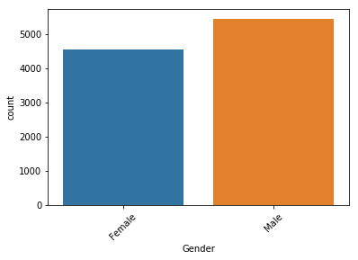

```python
#customer distribuition based on gender
sns.countplot(x ='Gender', data=data)
plt.xticks(rotation=45)
print(data[["Gender"]].groupby("Gender").size())

plt.show()
```

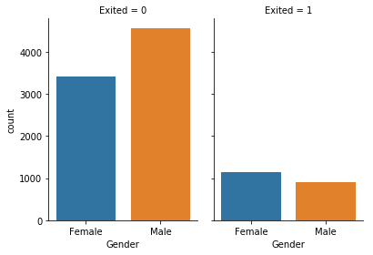

```python
#The number of customers Exited status based on their gender
sns.catplot(x="Gender", col="Exited",data=cdata, kind="count",height=4, aspect=.7)
plt.show()
```

More number of female customers are exiting

```
(-1.1166410801857136,
 1.2308345106001999,
 -1.1089393369061447,
 1.1197831209053932)
```

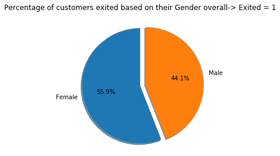

```python
female_exited = len(cdata.loc[(cdata['Exited']==1) & (cdata['Gender']=="Female")])
male_exited = len(cdata.loc[(cdata['Exited']==1) & (cdata['Gender']=="Male")])

size_gender_exited = [female_exited,male_exited]
labelgender= 'Female', 'Male'
explode = (0, 0.1)

fig1, ax1 = plt.subplots()
plt.suptitle("Percentage of customers exited based on their Gender overall-> Exited = 1")
ax1.pie(size_gender_exited, explode=explode, labels=labelgender, autopct='%1.1f%%',shadow=True, startangle=90)
ax1.axis('equal')
```

### Feature Engineering

```python
#copy original dataset to new variable fdata->feature_engineered dataset
fdata = data.copy()
fdata.head()
```

|  | RowNumber | CustomerId | Surname | CreditScore | Geography | Gender | Age | Tenure | Balance | NumOfProducts | HasCrCard | IsActiveMember | EstimatedSalary | Exited |
| --- | --- | --- | --- | --- | --- | --- | --- | --- | --- | --- | --- | --- | --- | --- |
| 0 | 1 | 15634602 | Hargrave | 619 | France | Female | 42 | 2 | 0.00 | 1 | 1 | 1 | 101348.88 | 1 |
| 1 | 2 | 15647311 | Hill | 608 | Spain | Female | 41 | 1 | 83807.86 | 1 | 0 | 1 | 112542.58 | 0 |
| 2 | 3 | 15619304 | Onio | 502 | France | Female | 42 | 8 | 159660.80 | 3 | 1 | 0 | 113931.57 | 1 |
| 3 | 4 | 15701354 | Boni | 699 | France | Female | 39 | 1 | 0.00 | 2 | 0 | 0 | 93826.63 | 0 |
| 4 | 5 | 15737888 | Mitchell | 850 | Spain | Female | 43 | 2 | 125510.82 | 1 | 1 | 1 | 79084.10 | 0 |

#### 1. Removing Unwanted features

In the dataset we see that **RowNumber and CustomerId** will not contribute to prediction of churnner. These features are unwanted and we will drop it from our dataset

```python
fdata = fdata.iloc[:,2:14]
fdata.head()
```

|  | Surname | CreditScore | Geography | Gender | Age | Tenure | Balance | NumOfProducts | HasCrCard | IsActiveMember | EstimatedSalary | Exited |
| --- | --- | --- | --- | --- | --- | --- | --- | --- | --- | --- | --- | --- |
| 0 | Hargrave | 619 | France | Female | 42 | 2 | 0.00 | 1 | 1 | 1 | 101348.88 | 1 |
| 1 | Hill | 608 | Spain | Female | 41 | 1 | 83807.86 | 1 | 0 | 1 | 112542.58 | 0 |
| 2 | Onio | 502 | France | Female | 42 | 8 | 159660.80 | 3 | 1 | 0 | 113931.57 | 1 |
| 3 | Boni | 699 | France | Female | 39 | 1 | 0.00 | 2 | 0 | 0 | 93826.63 | 0 |
| 4 | Mitchell | 850 | Spain | Female | 43 | 2 | 125510.82 | 1 | 1 | 1 | 79084.10 | 0 |

#### 2. Handling categorical data

From the above analysis we have seen that the feature **Surname** might contribute significant role in predicting churners. It has 2932 unique elements out of 10000 which means most of them are repeated only. But inorder to use this in any machine learning algorithm we need convert in numerical form because machine will not understand the text, it understands only number. So by **using Label encoding** convert it into numbers.

```python
from sklearn.preprocessing import LabelEncoder, OneHotEncoder

#converting Surname in numerical value using Label encoding
labelencoder = LabelEncoder()
fdata.iloc[:, 0] = labelencoder.fit_transform(fdata.iloc[:, 0])

fdata.head()
```

|  | Surname | CreditScore | Geography | Gender | Age | Tenure | Balance | NumOfProducts | HasCrCard | IsActiveMember | EstimatedSalary | Exited |
| --- | --- | --- | --- | --- | --- | --- | --- | --- | --- | --- | --- | --- |
| 0 | 1115 | 619 | France | Female | 42 | 2 | 0.00 | 1 | 1 | 1 | 101348.88 | 1 |
| 1 | 1177 | 608 | Spain | Female | 41 | 1 | 83807.86 | 1 | 0 | 1 | 112542.58 | 0 |
| 2 | 2040 | 502 | France | Female | 42 | 8 | 159660.80 | 3 | 1 | 0 | 113931.57 | 1 |
| 3 | 289 | 699 | France | Female | 39 | 1 | 0.00 | 2 | 0 | 0 | 93826.63 | 0 |
| 4 | 1822 | 850 | Spain | Female | 43 | 2 | 125510.82 | 1 | 1 | 1 | 79084.10 | 0 |

**Geography** feature is a categorical and it has three values - France,Germany and Spain. Similarly **Gender** feature is a categorical feature which has two values Female and Male. So need convert them into numerical form so that any alogrithm we apply will understand it and learn from it. Since their numbers are very small so we will just map them to numbers as shown below.

```python
for row in [fdata]:
    row["Gender"] = row["Gender"].map( {"Male": 0, "Female": 1} ).astype(int)
    row["Geography"] = row["Geography"].map( {"France": 0, "Germany": 1, "Spain": 2} ).astype(int)
fdata.head()
```

|  | Surname | CreditScore | Geography | Gender | Age | Tenure | Balance | NumOfProducts | HasCrCard | IsActiveMember | EstimatedSalary | Exited |
| --- | --- | --- | --- | --- | --- | --- | --- | --- | --- | --- | --- | --- |
| 0 | 1115 | 619 | 0 | 1 | 42 | 2 | 0.00 | 1 | 1 | 1 | 101348.88 | 1 |
| 1 | 1177 | 608 | 2 | 1 | 41 | 1 | 83807.86 | 1 | 0 | 1 | 112542.58 | 0 |
| 2 | 2040 | 502 | 0 | 1 | 42 | 8 | 159660.80 | 3 | 1 | 0 | 113931.57 | 1 |
| 3 | 289 | 699 | 0 | 1 | 39 | 1 | 0.00 | 2 | 0 | 0 | 93826.63 | 0 |
| 4 | 1822 | 850 | 2 | 1 | 43 | 2 | 125510.82 | 1 | 1 | 1 | 79084.10 | 0 |

Now all the data is in suitable format for using as input to any machine learning model. But we have features which varies from low value to high value for just two classes(i.e. the response classes). Can we do some feature engineering like transforming them into bins(range) so that it can more generalize the system for new data.

so consider the feature **CreditScore** first.

#### CreditScore transformation

```python
print("CreditScore maximum value :",fdata["CreditScore"].max())
print("CreditScore minimum value :",fdata["CreditScore"].min())
print("CreditScore mean value :",fdata["CreditScore"].mean())
```

```
CreditScore maximum value : 850
CreditScore minimum value : 350
CreditScore mean value : 650.5288
```

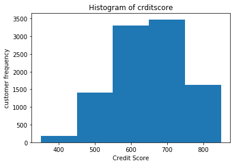

```python
bins = [350,450,550,650,750,850]

plt.hist(fdata["CreditScore"],bins,histtype='bar')

plt.title("Histogram of crditscore")
plt.xlabel('Credit Score')
plt.ylabel('customer frequency')
plt.show()
```

```python
if fdata["CreditScore"][0] > 4:
    fdata.loc[fdata["CreditScore"] <= 450, "CreditScoreRange"] = 0
    fdata.loc[(fdata["CreditScore"] > 450) & (fdata["CreditScore"] <= 550), "CreditScoreRange"] = 1
    fdata.loc[(fdata["CreditScore"] > 550) & (fdata["CreditScore"] <= 650), "CreditScoreRange"] = 2
    fdata.loc[(fdata["CreditScore"] > 650) & (fdata["CreditScore"] <= 750), "CreditScoreRange"] = 3
    fdata.loc[fdata["CreditScore"] > 750, "CreditScoreRange"] = 4
```

#### Age Transformation into range

```python
print("Age maximum value : ",fdata["Age"].max())
print("Age minimum value : ",fdata["Age"].min())
print("Age mean value : ",fdata["Age"].mean())
```

```
Age maximum value :  92
Age minimum value :  18
Age mean value :  38.9218
```

```python
if fdata["Age"][0] > 17:
    fdata.loc[fdata["Age"] <= 16, "AgeRange"] = 0
    fdata.loc[(fdata["Age"] > 16) & (fdata["Age"] <= 32),"AgeRange"] = 1
    fdata.loc[(fdata["Age"] > 32) & (fdata["Age"] <= 48),"AgeRange"] = 2
    fdata.loc[(fdata["Age"] > 48) & (fdata["Age"] <= 64),"AgeRange"] = 3
    fdata.loc[fdata["Age"] > 64,"AgeRange"] = 4

fdata.head(2)
```

|  | Surname | CreditScore | Geography | Gender | Age | Tenure | Balance | NumOfProducts | HasCrCard | IsActiveMember | EstimatedSalary | Exited | CreditScoreRange | AgeRange |
| --- | --- | --- | --- | --- | --- | --- | --- | --- | --- | --- | --- | --- | --- | --- |
| 0 | 1115 | 619 | 0 | 1 | 42 | 2 | 0.00 | 1 | 1 | 1 | 101348.88 | 1 | 2.0 | 2.0 |
| 1 | 1177 | 608 | 2 | 1 | 41 | 1 | 83807.86 | 1 | 0 | 1 | 112542.58 | 0 | 2.0 | 2.0 |

#### Balance transformation to range

```python
print("Maximum of Balance :",fdata["Balance"].max())
print("Minimum of Balance :",fdata["Balance"].min())
print("Mean of Balance :",fdata["Balance"].mean())
```

```
Maximum of Balance : 250898.09
Minimum of Balance : 0.0
Mean of Balance : 76485.88928799961
```

```python
if fdata["Balance"][1] > 4:
    fdata.loc[fdata["Balance"] <= 50000,"BalanceRange"] = 0
    fdata.loc[(fdata["Balance"] > 50000) & (fdata["Balance"] <= 100000), "BalanceRange"] = 1
    fdata.loc[(fdata["Balance"] > 100000) & (fdata["Balance"] <= 150000), "BalanceRange"] = 2
    fdata.loc[(fdata["Balance"] > 150000) & (fdata["Balance"] <= 200000), "BalanceRange"] = 3
    fdata.loc[fdata["Balance"] > 200000,"BalanceRange"] = 4

fdata.head(2)
```

|  | Surname | CreditScore | Geography | Gender | Age | Tenure | Balance | NumOfProducts | HasCrCard | IsActiveMember | EstimatedSalary | Exited | CreditScoreRange | AgeRange | BalanceRange |
| --- | --- | --- | --- | --- | --- | --- | --- | --- | --- | --- | --- | --- | --- | --- | --- |
| 0 | 1115 | 619 | 0 | 1 | 42 | 2 | 0.00 | 1 | 1 | 1 | 101348.88 | 1 | 2.0 | 2.0 | 0.0 |
| 1 | 1177 | 608 | 2 | 1 | 41 | 1 | 83807.86 | 1 | 0 | 1 | 112542.58 | 0 | 2.0 | 2.0 | 1.0 |

#### EstimatedSalary transformation to range

```python
print("Maximum of EstimatedSalary : ",fdata["EstimatedSalary"].max())
print("Minimum of EstimatedSalary : ",fdata["EstimatedSalary"].min())
print("Mean of EstimatedSalary : ",fdata["EstimatedSalary"].mean())
```

```
Maximum of EstimatedSalary :  199992.48
Minimum of EstimatedSalary :  11.58
Mean of EstimatedSalary :  100090.2398809998
```

```python
if fdata["EstimatedSalary"][0] > 4:
    fdata.loc[fdata["EstimatedSalary"] <= 40000,"EstimatedSalaryRange"] = 0
    fdata.loc[(fdata["EstimatedSalary"] > 40000) & (fdata["EstimatedSalary"] <= 80000),"EstimatedSalaryRange"]=1
    fdata.loc[(fdata["EstimatedSalary"] > 80000) & (fdata["EstimatedSalary"] <= 120000),"EstimatedSalaryRange"]=2
    fdata.loc[(fdata["EstimatedSalary"] > 120000) & (fdata["EstimatedSalary"] <= 160000),"EstimatedSalaryRange"]=3
    fdata.loc[fdata["EstimatedSalary"] > 160000,"EstimatedSalaryRange"] = 4
fdata.head()
```

|  | Surname | CreditScore | Geography | Gender | Age | Tenure | Balance | NumOfProducts | HasCrCard | IsActiveMember | EstimatedSalary | Exited | CreditScoreRange | AgeRange | BalanceRange | EstimatedSalaryRange |
| --- | --- | --- | --- | --- | --- | --- | --- | --- | --- | --- | --- | --- | --- | --- | --- | --- |
| 0 | 1115 | 619 | 0 | 1 | 42 | 2 | 0.00 | 1 | 1 | 1 | 101348.88 | 1 | 2.0 | 2.0 | 0.0 | 2.0 |
| 1 | 1177 | 608 | 2 | 1 | 41 | 1 | 83807.86 | 1 | 0 | 1 | 112542.58 | 0 | 2.0 | 2.0 | 1.0 | 2.0 |
| 2 | 2040 | 502 | 0 | 1 | 42 | 8 | 159660.80 | 3 | 1 | 0 | 113931.57 | 1 | 1.0 | 2.0 | 3.0 | 2.0 |
| 3 | 289 | 699 | 0 | 1 | 39 | 1 | 0.00 | 2 | 0 | 0 | 93826.63 | 0 | 3.0 | 2.0 | 0.0 | 2.0 |
| 4 | 1822 | 850 | 2 | 1 | 43 | 2 | 125510.82 | 1 | 1 | 1 | 79084.10 | 0 | 4.0 | 2.0 | 2.0 | 1.0 |

#### Now replace the orginal feature with their corresponding range value to get the final feature_engineered dataset

```python
if "CreditScoreRange" in fdata.columns:
    fdata["CreditScore"] = fdata["CreditScoreRange"]
if "AgeRange" in fdata.columns:
    fdata["Age"] = fdata["AgeRange"]
if "BalanceRange" in fdata.columns:
    fdata["Balance"] = fdata["BalanceRange"]
if "EstimatedSalaryRange" in fdata.columns:
    fdata["EstimatedSalary"] = fdata["EstimatedSalaryRange"]

#now drop the range-valued column
if "CreditScoreRange" in fdata.columns:
    fdata = fdata.drop(["CreditScoreRange"],axis=1)
if "AgeRange" in fdata.columns:
    fdata = fdata.drop(["AgeRange"],axis=1)
if "BalanceRange" in fdata.columns:
    fdata = fdata.drop(["BalanceRange"],axis=1)
if "EstimatedSalaryRange" in fdata.columns:
    fdata = fdata.drop(["EstimatedSalaryRange"],axis=1)

#rename the corresponding columns in the form of range
fdata = fdata.rename(columns={'CreditScore': 'CreditScoreRange', 'Age': 'AgeRange', 'Balance': 'BalanceRange',\
                              'EstimatedSalary': 'EstimatedSalaryRange'})

print("\nThis is our full engineered dataset")
fdata.head()
```

```
This is our full engineered dataset
```

|  | Surname | CreditScoreRange | Geography | Gender | AgeRange | Tenure | BalanceRange | NumOfProducts | HasCrCard | IsActiveMember | EstimatedSalaryRange | Exited |
| --- | --- | --- | --- | --- | --- | --- | --- | --- | --- | --- | --- | --- |
| 0 | 1115 | 2.0 | 0 | 1 | 2.0 | 2 | 0.0 | 1 | 1 | 1 | 2.0 | 1 |
| 1 | 1177 | 2.0 | 2 | 1 | 2.0 | 1 | 1.0 | 1 | 0 | 1 | 2.0 | 0 |
| 2 | 2040 | 1.0 | 0 | 1 | 2.0 | 8 | 3.0 | 3 | 1 | 0 | 2.0 | 1 |
| 3 | 289 | 3.0 | 0 | 1 | 2.0 | 1 | 0.0 | 2 | 0 | 0 | 2.0 | 0 |
| 4 | 1822 | 4.0 | 2 | 1 | 2.0 | 2 | 2.0 | 1 | 1 | 1 | 1.0 | 0 |

### Analysis of data on featues CreditScoreRange, AgeRange, BalanceRange, EstimatedSalaryRange

```python
#copy the feature_engineered data for our analyis fadata -> feature analysis data
fadata = fdata.copy()
```

#### CreditScoreRange

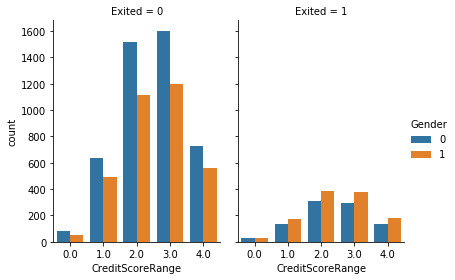

```python
#The number of customers Exited based on CreditScoreRange
sns.catplot(x="CreditScoreRange",hue='Gender', col="Exited",data=fadata, kind="count",height=4, aspect=.7)
plt.show()
```

```
(-1.2032288638444193,
 1.2125052844594546,
 -1.1813424570957456,
 1.2081720891106387)
```

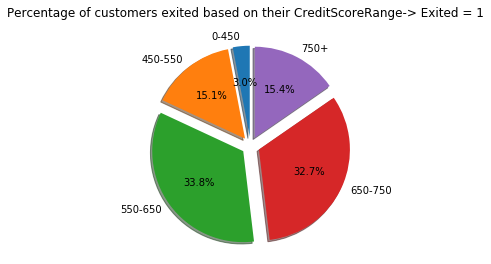

```python
#analyzing the percentage of each creditscorerange
exited0 = len(fadata.loc[(fadata['Exited']==1) & (fadata['CreditScoreRange']== 0.0)])
exited1 = len(fadata.loc[(fadata['Exited']==1) & (fadata['CreditScoreRange']== 1.0)])
exited2 = len(fadata.loc[(fadata['Exited']==1) & (fadata['CreditScoreRange']== 2.0)])
exited3 = len(fadata.loc[(fadata['Exited']==1) & (fadata['CreditScoreRange']== 3.0)])
exited4 = len(fadata.loc[(fadata['Exited']==1) & (fadata['CreditScoreRange']== 4.0)])

size_creditscore_exited = [exited0,exited1,exited2,exited3,exited4]
labelcrditscore= '0-450', '450-550','550-650','650-750','750+'
explode = (0.1, 0.1,0.1,0.1,0.1)

fig1, ax1 = plt.subplots()
plt.suptitle("Percentage of customers exited based on their CreditScoreRange-> Exited = 1")
ax1.pie(size_creditscore_exited, explode=explode, labels=labelcrditscore, autopct='%1.1f%%',shadow=True, \
        startangle=90)
ax1.axis('equal')
```

From the above pie chart we can say that customers with CreditScore range 550-650 have high percentage of exiting.

#### AgeRange Analysis

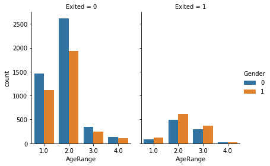

```python
#The number of customers Exited based on AgeRange
sns.catplot(x="AgeRange",hue='Gender', col="Exited",data=fadata, kind="count",height=4, aspect=.7)
plt.show()
```

```
(-1.1118219055579734,
 1.209556566762656,
 -1.1295414300334992,
 1.5195332054659532)
```

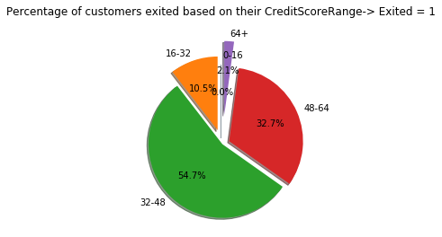

```python
#analyzing the percentage of each creditscorerange
exited_ar0 = len(fadata.loc[(fadata['Exited']==1) & (fadata['AgeRange']== 0.0)])
exited_ar1 = len(fadata.loc[(fadata['Exited']==1) & (fadata['AgeRange']== 1.0)])
exited_ar2 = len(fadata.loc[(fadata['Exited']==1) & (fadata['AgeRange']== 2.0)])
exited_ar3 = len(fadata.loc[(fadata['Exited']==1) & (fadata['AgeRange']== 3.0)])
exited_ar4 = len(fadata.loc[(fadata['Exited']==1) & (fadata['AgeRange']== 4.0)])

size_age_exited = [exited_ar0,exited_ar1,exited_ar2,exited_ar3,exited_ar4]
labelage= '0-16', '16-32','32-48','48-64','64+'
explode = (0.1,0.2,0,0.1,0.4)

fig1, ax1 = plt.subplots()
plt.suptitle("Percentage of customers exited based on their CreditScoreRange-> Exited = 1")
ax1.pie(size_age_exited, explode=explode, labels=labelage, autopct='%1.1f%%',shadow=True, \
        startangle=90)
ax1.axis('equal')
```

#### BalanceRange Analysis

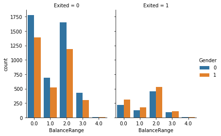

```python
#The number of customers Exited based on BalanceRange
sns.catplot(x="BalanceRange",hue='Gender', col="Exited",data=fadata, kind="count",height=4, aspect=.7)
plt.show()
```

```
(-1.2825966729175229,
 1.1331803497815867,
 -1.1502216190356263,
 1.521259226489057)
```

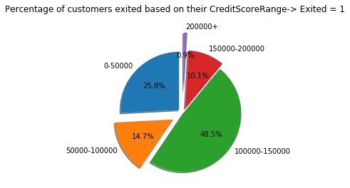

```python
#analyzing the percentage of each BalanceRange
exited_br0 = len(fadata.loc[(fadata['Exited']==1) & (fadata['BalanceRange']== 0.0)])
exited_br1 = len(fadata.loc[(fadata['Exited']==1) & (fadata['BalanceRange']== 1.0)])
exited_br2 = len(fadata.loc[(fadata['Exited']==1) & (fadata['BalanceRange']== 2.0)])
exited_br3 = len(fadata.loc[(fadata['Exited']==1) & (fadata['BalanceRange']== 3.0)])
exited_br4 = len(fadata.loc[(fadata['Exited']==1) & (fadata['BalanceRange']== 4.0)])

size_balance_exited = [exited_br0,exited_br1,exited_br2,exited_br3,exited_br4]
labelbalance= '0-50000', '50000-100000','100000-150000','150000-200000','200000+'
explode = (0.1,0.2,0,0.1,0.4)

fig1, ax1 = plt.subplots()
plt.suptitle("Percentage of customers exited based on their CreditScoreRange-> Exited = 1")
ax1.pie(size_balance_exited, explode=explode, labels=labelbalance, autopct='%1.1f%%',shadow=True, \
        startangle=90)
ax1.axis('equal')
```

#### EstimatedSalary Analysis

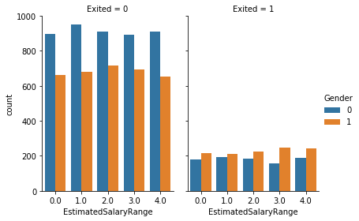

```python
#The number of customers Exited based on BalanceRange
sns.catplot(x="EstimatedSalaryRange",hue='Gender', col="Exited",data=fadata, kind="count",height=4, aspect=.7)
plt.show()
```

```
(-1.2825966729175229,
 1.1331803497815867,
 -1.1502216190356263,
 1.521259226489057)
```

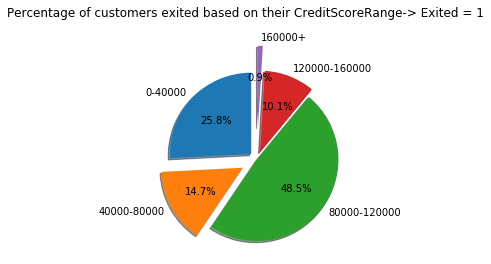

```python
#analyzing the percentage of each BalanceRange
exited_esr0 = len(fadata.loc[(fadata['Exited']==1) & (fadata['EstimatedSalaryRange']== 0.0)])
exited_esr1 = len(fadata.loc[(fadata['Exited']==1) & (fadata['EstimatedSalaryRange']== 1.0)])
exited_esr2 = len(fadata.loc[(fadata['Exited']==1) & (fadata['EstimatedSalaryRange']== 2.0)])
exited_esr3 = len(fadata.loc[(fadata['Exited']==1) & (fadata['EstimatedSalaryRange']== 3.0)])
exited_esr4 = len(fadata.loc[(fadata['Exited']==1) & (fadata['EstimatedSalaryRange']== 4.0)])

size_estimated_exited = [exited_br0,exited_br1,exited_br2,exited_br3,exited_br4]
labelestimated= '0-40000', '40000-80000','80000-120000','120000-160000','160000+'
explode = (0.1,0.2,0,0.1,0.4)

fig1, ax1 = plt.subplots()
plt.suptitle("Percentage of customers exited based on their CreditScoreRange-> Exited = 1")
ax1.pie(size_estimated_exited, explode=explode, labels=labelestimated, autopct='%1.1f%%',shadow=True, \
        startangle=90)
ax1.axis('equal')
```

## Applying Neural Network

```python
#create a copy of our dataset -> data as cdata
fdatacnn = fdata.copy()

fdatacnn.head(5)
```

|  | Surname | CreditScoreRange | Geography | Gender | AgeRange | Tenure | BalanceRange | NumOfProducts | HasCrCard | IsActiveMember | EstimatedSalaryRange | Exited |
| --- | --- | --- | --- | --- | --- | --- | --- | --- | --- | --- | --- | --- |
| 0 | 1115 | 2.0 | 0 | 1 | 2.0 | 2 | 0.0 | 1 | 1 | 1 | 2.0 | 1 |
| 1 | 1177 | 2.0 | 2 | 1 | 2.0 | 1 | 1.0 | 1 | 0 | 1 | 2.0 | 0 |
| 2 | 2040 | 1.0 | 0 | 1 | 2.0 | 8 | 3.0 | 3 | 1 | 0 | 2.0 | 1 |
| 3 | 289 | 3.0 | 0 | 1 | 2.0 | 1 | 0.0 | 2 | 0 | 0 | 2.0 | 0 |
| 4 | 1822 | 4.0 | 2 | 1 | 2.0 | 2 | 2.0 | 1 | 1 | 1 | 1.0 | 0 |

```python
from sklearn.preprocessing import LabelEncoder, OneHotEncoder

X = fdatacnn.copy()

#dropping teh RowNumber and CustomerId column because these will not have any effect on the churn prediction
X = X.iloc[:,1:12]
```

```python
#X = pd.DataFrame(X)
X.head()
```

|  | CreditScoreRange | Geography | Gender | AgeRange | Tenure | BalanceRange | NumOfProducts | HasCrCard | IsActiveMember | EstimatedSalaryRange | Exited |
| --- | --- | --- | --- | --- | --- | --- | --- | --- | --- | --- | --- |
| 0 | 2.0 | 0 | 1 | 2.0 | 2 | 0.0 | 1 | 1 | 1 | 2.0 | 1 |
| 1 | 2.0 | 2 | 1 | 2.0 | 1 | 1.0 | 1 | 0 | 1 | 2.0 | 0 |
| 2 | 1.0 | 0 | 1 | 2.0 | 8 | 3.0 | 3 | 1 | 0 | 2.0 | 1 |
| 3 | 3.0 | 0 | 1 | 2.0 | 1 | 0.0 | 2 | 0 | 0 | 2.0 | 0 |
| 4 | 4.0 | 2 | 1 | 2.0 | 2 | 2.0 | 1 | 1 | 1 | 1.0 | 0 |

```python
from sklearn.model_selection import train_test_split
# fix random seed for reproducibility
seed = 2
np.random.seed(seed)

dataX = X.iloc[:,:10]
dataY = X.iloc[:,10]

# percentage of xtrain which will be xval
split_pct = 0.3

# Split the train and the validation set
xtrain, xval, ytrain, yval = train_test_split(dataX,
                                              dataY,
                                              test_size=split_pct,
                                              random_state=seed,
                                              shuffle=True
                                             )
```

```python
print("xtrain :",xtrain.shape)
print("ytrain :",ytrain.shape)
print("xval :",xval.shape)
print("yval :",yval.shape)
```

```
xtrain : (7000, 10)
ytrain : (7000,)
xval : (3000, 10)
yval : (3000,)
```

```python
# Importing Keras
import keras
from keras.models import Sequential
from keras.layers import Dense
```

```python
#initializing out squential network based artificial neural network
model = Sequential()
#first hidden layer with 6 neurons in it
model.add(Dense(output_dim = 6, init = 'uniform', activation = 'relu', input_dim = 10))
#second hiddent layer with 6 neurons in it
model.add(Dense(output_dim = 6, init = 'uniform', activation = 'relu'))
# final output layer with single neuron
model.add(Dense(output_dim = 1, init = 'uniform', activation = 'sigmoid'))


#compiling teh model using loss as binary_crossentropy (as we have binary classification problem), optimizer as adam
model.compile(optimizer = 'adam', loss = 'binary_crossentropy', metrics = ['accuracy'])

#fit the model with our training dataset
model.fit(xtrain, ytrain, batch_size = 10, nb_epoch = 100)

#now it's time to make prediction on our X_test data set
predict_y = model.predict(xval)

predict_y = (predict_y > 0.5)
```

```python
from sklearn.metrics import confusion_matrix
cm = confusion_matrix(yval, predict_y)
print(cm)
```

```
[[2276  139]
 [ 455  130]]
```

# Applying Logistic Regression

```python
#create a copy of our dataset -> data as cdata
fdatalogistic = fdata.copy()

fdatalogistic.head(5)
```

|  | Surname | CreditScoreRange | Geography | Gender | AgeRange | Tenure | BalanceRange | NumOfProducts | HasCrCard | IsActiveMember | EstimatedSalaryRange | Exited |
| --- | --- | --- | --- | --- | --- | --- | --- | --- | --- | --- | --- | --- |
| 0 | 1115 | 2.0 | 0 | 1 | 2.0 | 2 | 0.0 | 1 | 1 | 1 | 2.0 | 1 |
| 1 | 1177 | 2.0 | 2 | 1 | 2.0 | 1 | 1.0 | 1 | 0 | 1 | 2.0 | 0 |
| 2 | 2040 | 1.0 | 0 | 1 | 2.0 | 8 | 3.0 | 3 | 1 | 0 | 2.0 | 1 |
| 3 | 289 | 3.0 | 0 | 1 | 2.0 | 1 | 0.0 | 2 | 0 | 0 | 2.0 | 0 |
| 4 | 1822 | 4.0 | 2 | 1 | 2.0 | 2 | 2.0 | 1 | 1 | 1 | 1.0 | 0 |

```python
from sklearn.model_selection import train_test_split
# fix random seed for reproducibility
seed = 2
np.random.seed(seed)

dataX = fdatalogistic.iloc[:,1:11]
dataY = fdatalogistic.iloc[:,11]

# percentage of xtrain which will be xval
split_pct = 0.3

# Split the train and the validation set
xtrain, xval, ytrain, yval = train_test_split(dataX,
                                              dataY,
                                              test_size=split_pct,
                                              random_state=seed,
                                              shuffle=True
                                             )
```

```python
from sklearn.linear_model import LogisticRegression
# Logistic Regression

logistic_regression = LogisticRegression()
logistic_regression.fit(xtrain, ytrain)
Y_pred = logistic_regression.predict(xval)
#print(Y_pred)
acc_log = round(logistic_regression.score(xval, yval), 3)
print("accuracy:", acc_log)
```

```
accuracy: 0.819
```

# Applying RandomForest Algorithm

```python
from sklearn.model_selection import train_test_split
from sklearn.ensemble import RandomForestClassifier
#Import scikit-learn metrics module for accuracy calculation
from sklearn import metrics

rfdata = fdata.copy()
rfdata.head()
```

|  | Surname | CreditScoreRange | Geography | Gender | AgeRange | Tenure | BalanceRange | NumOfProducts | HasCrCard | IsActiveMember | EstimatedSalaryRange | Exited |
| --- | --- | --- | --- | --- | --- | --- | --- | --- | --- | --- | --- | --- |
| 0 | 1115 | 2.0 | 0 | 1 | 2.0 | 2 | 0.0 | 1 | 1 | 1 | 2.0 | 1 |
| 1 | 1177 | 2.0 | 2 | 1 | 2.0 | 1 | 1.0 | 1 | 0 | 1 | 2.0 | 0 |
| 2 | 2040 | 1.0 | 0 | 1 | 2.0 | 8 | 3.0 | 3 | 1 | 0 | 2.0 | 1 |
| 3 | 289 | 3.0 | 0 | 1 | 2.0 | 1 | 0.0 | 2 | 0 | 0 | 2.0 | 0 |
| 4 | 1822 | 4.0 | 2 | 1 | 2.0 | 2 | 2.0 | 1 | 1 | 1 | 1.0 | 0 |

```python
dataX = rfdata.iloc[:,1:11]
dataY = rfdata.iloc[:,11]

#splitting the data into train set and test set - 70% train and 30% test
X_train, X_test, y_train, y_test = train_test_split(dataX, dataY, test_size=0.3)

#Create a Gaussian Classifier
rfmodel=RandomForestClassifier(n_estimators=100)

#train the model
rfmodel.fit(X_train,y_train)

#predicting on test dataset
rf_y_pred=rfmodel.predict(X_test)

print("Accuracy:",metrics.accuracy_score(y_test, rf_y_pred))
```

```
Accuracy: 0.839
```

## Thank you

### Sanjeet kumar

School of AI, Hubli  
sanjeetiiitd@gmail.com